# toronto_analysis

This report will be cleaning OpenStreetMap data of Toronto, Ontario. I chose this city because I am from Mississauga,a neighbouring city of Toronto and also because this is the biggest city in Canada and I'm interested in finding and sharing interesting facts about the city.

I started by finding all the unique k values of the tags. And then I decided to look into specific key,value pairs to look for inconsistencies. I chose them randomly or the ones I wanted to look more into, or ones that are likely to have inconsistencies for example "addr:street" and "addr:province".

Here are a couple of inconsistencies I found:

1. Street types were inconsistent
2. Province name was written differently or inaccurately multiple times
3. Same cuisine types were written in multiple ways for example, arabic cuisines were written "arabic", "arab"

I found these inconsistencies through some basic database querying and also through prgramming. If I found an inconsistency through querying that I hadn't found earlier, I went back and adjusted the code so the next time the xml file is exported to csv file, the changes are made and the errors are handled. The code first creates a sample file using using k=10, so every 10th element. I used a small number like 10 so I can get a better feel of what the data is like. The new sample file is called "toronto_sample.osm". The analysis I did throughout this report is based on k=10, the info in the csv files were also imported based on k=10. The "toronto_sample.osm" sample file that I submitted is k=140, to compress the file down to 10MB or under. The original osm file downloaded from openstreetmap is 1.12GB and the sample file that is k=10 is 119MB.

```python
import xml.etree.cElementTree as ET
import pprint
from collections import defaultdict
import re
import csv
import codecs
import pprint

import cerberus

import schema

## Creating a sample file
k = 140

def get_element(osm_file, tags=('node', 'way', 'relation')):
    context = iter(ET.iterparse(osm_file, events=('start','end')))
    _, root = next(context)
    for event,elem in context:
        if event == 'end' and elem.tag in tags:
            yield elem
            root.clear()

with open('toronto_sample.osm', 'wb') as output:
    output.write('<?xml version="1.0" encoding="UTF-8"?>\n')
    output.write('<osm>\n  ')

    for i,element in enumerate(get_element('toronto_canada.osm')):
        if i % k == 0:
            output.write(ET.tostring(element, encoding='utf-8'))

    output.write('</osm>')
```

AUDITING PROCESS

The first thing I did was see all the different types of tags there are in the data like we did in the case study. The different types of tags are listed in the cell below. By finding the different types of tags I know what places to look into and how to structure the rest of my code. I put most emphasis on the node, way and tag elements because they are likely to have errors and also they play a vital role in creating details of the map. For example, nodes are all fixed locations of a place so it is important that they are consistent. Tags reveal description and attributes of a certain place, so it is necessary to check there for errors so the map doesn't give any wrong information. Things like wrong spelling, writing one type/attribute in multiple ways can create confusion. The count_tags(filename) function below shows all the different tags/elements in the data.

```python
## Get all unique tags (from case study, mapparser.py)
import xml.etree.cElementTree as ET

def count_tags(filename):
        # YOUR CODE HERE
        tags = {}
        parser = ET.iterparse(filename)
        for __, elem in parser:
            if elem.tag in tags:
                tags[elem.tag] += 1
            else:
                tags[elem.tag] = 1

            elem.clear()
        del parser
        return tags


## Get all unique k values
def get_unique_k_values(filename):
    osm_file = open(filename,"r")
    name_types = set()
    for __, elem in ET.iterparse(filename, events=("start",)):

        if elem.tag == "node" or elem.tag == "way" or elem.tag == "relation":
            for tag in elem.iter('tag'):
                try:
                    name_types.add(tag.attrib['k'])
                except KeyError:
                    continue

    print name_types

## Run get_unique_k_values('toronto_sample.osm') to see all the different k values
count_tags("toronto_sample.osm")
```

```
{'member': 9793,
 'nd': 580000,
 'node': 501905,
 'osm': 1,
 'relation': 905,
 'tag': 494268,
 'way': 74540}
```

AUDITING PROCESS CONTINUED...

The cell belows finds the last word and finds the v values of a specific given k value. This is the code I used to find inconsistencies within the province names and street types. The audit1() function works by taking in as input the type of k value you are trying to find. So for example as shown in the code below, audit1("addr:province") looks for all k values that are "addr:province" and then finds its v values. It then prints out all the unique different v values and how many of them there are. If we look in the results below we see that ontario is written in number of different ways. As I predicted earlier and as we saw in the case study during the lesson, the "addr:province" tag is likely to have errors. The province names are inconsistent in this case. I will talk more about how I handle this error in the last cell. I found this code in the lessons in the data wrangling course. Although not shown below because the answer list is too large, I used audit1("addr:street") to find all the different ways the street names are written and fix any inconsistencies there.

```python
## Taking out v values to check for inconsistencies

street_type_re = re.compile(r'\b\S+\.?$', re.IGNORECASE)
street_types = defaultdict(int)

def audit_street_type(street_types, street_name):
    m = street_type_re.search(street_name)
    if m:
        street_type = m.group()
        street_types[street_type] += 1

def print_sorted_dict(d):
    keys = d.keys()
    keys = sorted(keys, key=lambda s:s.lower())
    for k in keys:
        v = d[k]
        print "%s: %d" % (k,v)

## Use this function to check if it has the tag value we're looking for in audit1
def is_name(elem, name_type):
    return (elem.attrib['k'] == name_type)

## Find the number of and different values of k with a certain key
def audit1(name_type):
    osm_file = open("toronto_sample.osm")
    print name_type, "\n"
    for event, elem in ET.iterparse(osm_file, events=("start",)):
        if elem.tag == "way" or elem.tag == "node" or elem.tag == "relation":
            for tag in elem.iter("tag"):
                if is_name(tag, name_type):
                    audit_street_type(street_types, tag.attrib['v'])

    osm_file.close()
    print_sorted_dict(street_types)
    street_types.clear()


audit1("addr:province")
```

```
addr:province

ON: 3440
on: 2
On: 1
Onatrio: 1
Ontario: 60
ontario: 1
```

The cell below has the functions that handle street type errors. If the street type in the xml file isn't like the one in the 'expected' list, then it is converted accordingly. For example St is converted to Street. Run audit('toronto_sample.osm') here to see how unexpected street types are handled. This function isnt used to export the xml file information to csv, this function is used to get a overview of the xml file like we did in the case study. The update_name function is used later in the load_new_tag() function, which is the main function that handles node tags, ways tags and errors found within them before exporting them to the csv file.

```python
## Handle street error (code structure taken from case study, audit.py)
street_type_re = re.compile(r'\b\S+\.?$', re.IGNORECASE)


expected = ["Street", "Avenue", "Boulevard", "Drive", "Court", "Place", "Square", "Lane", "Road",
            "Trail", "Parkway"]

## Convert the street types in the map to the preffered one
mapping = { "St": "Street",
            "Rd":"Road",
            "Dr.":"Drive",
             "W": "West",
               "N":"North",
               "E":"East"
            }

def audit_street_type1(street_types, street_name):
    m = street_type_re.search(street_name)
    if m:
        street_type = m.group()
        if street_type not in expected:
            street_types[street_type].add(street_name)

def is_street_name(elem):
    return (elem.attrib['k'] == "addr:street")


def audit(osmfile):
    osm_file = open(osmfile, "r")
    street_types = defaultdict(set)
    for event, elem in ET.iterparse(osm_file, events=("start",)):

        if elem.tag == "node" or elem.tag == "way":
            for tag in elem.iter("tag"):
                if is_street_name(tag):
                    audit_street_type1(street_types, tag.attrib['v'])
    osm_file.close()
    return street_types

## Updates last part of the given street accordingly
def update_name(name, mapping):

    m = street_type_re.search(name)
    better_name = name
    if m:
        better_street_type = mapping[m.group()]
        better_name = street_type_re.sub(better_street_type,name)

    return better_name
```

AUDITING PROCESS CONTINUED..

The load_new_tag() function in the cell below handles the problem for inconsistent names. I found all the different ways the province name was written in the earlier cell where I found the v values for k="addr:province". In the cell below in the load_new_tag() function I created an array with all the inconsistent province names and then run a "if" statement, to check if the v value for the province in the xml file is in the array, and if the value in the xml file is one in the array then I convert it to "ON". This same function also handles street type errors. The load_new_tag() function also takes care of other inconsistencies I found through querying with the SQL database such as cuisine errors. The idea here is to check for the inconsistencies, adjust the code again accordingly to handle the error and then insert into the csv files again as seen fit. I created the query "SELECT key,COUNT(*) as count FROM nodes_tags GROUP BY key ORDER BY count DESC" to see all the types of k values there are. Then I executed "SELECT key,value FROM nodes_tags WHERE key='keyvalue' GROUP BY value" and then saw all the different values for that k attribute. I then skimmed over the data to find inconsistencies. If I found an inconsistency I adjusted the load_new_tag() to make changes and fix the error.

```python
## This cell cleans and inserts the information from the xml file to csv file (code structure taken from case
## study and github https://github.com/davidventuri/udacity-dand/blob/master/p3/process_osm.py#L384)

NODES_PATH = "nodes.csv"
NODE_TAGS_PATH = "nodes_tags.csv"
WAYS_PATH = "ways.csv"
WAY_NODES_PATH = "ways_nodes.csv"
WAY_TAGS_PATH = "ways_tags.csv"

LOWER_COLON = re.compile(r'^([a-z]|_)+:([a-z]|_)+')
PROBLEMCHARS = re.compile(r'[=\+/&<>;\'"\?%#$@\,\. \t\r\n]')

NODE_FIELDS = ['id', 'lat', 'lon', 'user', 'uid', 'version', 'changeset', 'timestamp']
NODE_TAGS_FIELDS = ['id', 'key', 'value', 'type']
WAY_FIELDS = ['id', 'user', 'uid', 'version', 'changeset', 'timestamp']
WAY_TAGS_FIELDS = ['id', 'key', 'value', 'type']
WAY_NODES_FIELDS = ['id', 'node_id', 'position']


def get_element(osm_file, tags=('node', 'way','relation')):
    context = ET.iterparse(osm_file, events=('start','end'))
    _,root = next(context)

    for event,elem in context:
        if event == "end" and elem.tag in tags:
            yield elem
            root.clear()

class UnicodeDictWriter(csv.DictWriter, object):
    """Extend csv.DictWriter to handle Unicode input"""

    def writerow(self, row):
        super(UnicodeDictWriter, self).writerow({
            k: (v.encode('utf-8') if isinstance(v, unicode) else v) for k, v in row.iteritems()
        })

    def writerows(self, rows):
        for row in rows:
            self.writerow(row)


def load_new_tag(element,secondary,default_tag_type):
    new = {}
    new['id'] = element.attrib['id']
    if ":" not in secondary.attrib['k']:
        new['key'] = secondary.attrib['k']
        new['type'] = default_tag_type

    else:
        post_colon = secondary.attrib['k'].index(":") + 1
        new['key'] = secondary.attrib['k'][post_colon:]
        new['type'] = secondary.attrib['k'][:post_colon-1]

    ## Hanldes street type errors
    if is_street_name(secondary):
        try:
            street_name = update_name(secondary.attrib['v'],mapping)
            new['value'] = street_name
        except KeyError:
            new['value'] = secondary.attrib['v']

    ## Handle province name errors
    elif new['key'] == 'province' or new['key'] == 'state':
        inconsistent_name = ['on', 'On', 'Onatrio', 'Ontario','ontario']
        province_name = secondary.attrib['v']
        if province_name is in inconsistent_name:
            province_name = 'ON'
        new['value'] = province_name

    ## Handle cuisine type errors
    elif new['key'] == 'cuisine':
        value1 = secondary.attrib['v']
        if value1 == 'arab':
            value1 = 'arabic'
        elif value1 == 'asian;japanese':
            value1 = 'japanese'
        elif value1 == 'vietmanese':
            value1 = 'vietnamese'
        elif value1 == 'afghani':
            value1 = 'afghan'

        new['value'] = value1

    ## Handle country name errors Converts Canada to "CA"
    elif new['key'] == 'country':
        value1 = secondary.attrib['v']
        if value1 == 'Canada':
            value1 = "CA"

        new['value'] = value1

    else:
        new['value'] = secondary.attrib['v']

    return new


def shape_element(element,node_attr_fields=NODE_FIELDS,way_attr_fields=WAY_FIELDS,problem_chars=PROBLEMCHARS,
                 default_tag_type='regular'):

    node_attribs = {}
    way_attribs = {}
    way_nodes = []
    tags = []

    if element.tag == "node":
        for attrib,value in element.attrib.iteritems():
            if attrib in node_attr_fields:
                node_attribs[attrib] = value

        for secondary in element.iter():
            if secondary.tag == 'tag':
                if problem_chars.match(secondary.attrib['k']) is not None:
                    continue
                else:
                    new = load_new_tag(element, secondary, default_tag_type)
                    if new is not None:
                        tags.append(new)

        return {'node':node_attribs, 'node_tags':tags}

    if element.tag=="way":
        for attrib,value in element.attrib.iteritems():
            if attrib in way_attr_fields:
                way_attribs[attrib] = value

        counter = 0
        for secondary in element.iter():
            if secondary.tag == "tag":
                if problem_chars.match(secondary.attrib['k']) is not None:
                    continue
                else:
                    new = load_new_tag(element, secondary, default_tag_type)
                    if new is not None:
                        tags.append(new)

            if secondary.tag == 'nd':
                newnd = {}
                newnd['id'] = element.attrib['id']
                newnd['node_id'] = secondary.attrib['ref']
                newnd['position'] = counter
                counter += 1
                way_nodes.append(newnd)

        return {'way':way_attribs, 'way_nodes':way_nodes, 'way_tags':tags}

def process_map(file_in, validate):

    with codecs.open(NODES_PATH, "w") as nodes_file,codecs.open(NODE_TAGS_PATH, "w") as nodes_tags_file,codecs.open(WAYS_PATH, "w") as ways_file, codecs.open(WAY_NODES_PATH, "w") as way_nodes_file,codecs.open(WAY_TAGS_PATH, "w") as way_tags_file:

        nodes_writer = UnicodeDictWriter(nodes_file, NODE_FIELDS)
        node_tags_writer = UnicodeDictWriter(nodes_tags_file, NODE_TAGS_FIELDS)
        ways_writer = UnicodeDictWriter(ways_file, WAY_FIELDS)
        way_tags_writer = UnicodeDictWriter(way_tags_file, WAY_TAGS_FIELDS)
        way_nodes_writer = UnicodeDictWriter(way_nodes_file, WAY_NODES_FIELDS)

        nodes_writer.writeheader()
        node_tags_writer.writeheader()
        ways_writer.writeheader()
        way_nodes_writer.writeheader()
        way_tags_writer.writeheader()

        validator = cerberus.Validator()

        for element in get_element(file_in, tags=('node', 'way')):
            el = shape_element(element)
            if el:

                if element.tag == 'node':
                    nodes_writer.writerow(el['node'])
                    node_tags_writer.writerows(el['node_tags'])
                elif element.tag=='way':
                    ways_writer.writerow(el['way'])
                    way_nodes_writer.writerows(el['way_nodes'])
                    way_tags_writer.writerows(el['way_tags'])



process_map("toronto_sample.osm", validate=True)
```

```python
import sqlite3
import csv
from pprint import pprint

sqlite_file = "mydv.db"
conn = sqlite3.connect(sqlite_file)
cur = conn.cursor()

## Load nodes.csv into database
cur.execute('DROP TABLE IF EXISTS nodes')
conn.commit()
cur.execute(''' CREATE TABLE nodes(id INTEGER, lat FLOAT, lon FLOAT, user TEXT, uid INTEGER, version INTEGER,
            changeset INTEGER, timestamp TEXT)''')
conn.commit()
with open("nodes.csv", "rb") as fin:
    dr = csv.DictReader(fin)
    to_db = [(i['id'].decode("utf-8"), i['lat'].decode("utf-8"), i['lon'].decode("utf-8"),
              i['user'].decode("utf-8"), i['uid'].decode("utf-8"),i['version'].decode("utf-8"),
              i['changeset'].decode("utf-8"),i['timestamp']) for i in dr]
cur.executemany("INSERT INTO nodes(id,lat,lon,user,uid,version,changeset,timestamp) VALUES(?,?,?,?,?,?,?,?);", to_db)
conn.commit()

## Load ways_nodes.csv into database
cur.execute('DROP TABLE IF EXISTS ways_nodes')
conn.commit()
cur.execute(''' CREATE TABLE ways_nodes(id INTEGER, node_id INTEGER, position INTEGER)''')
conn.commit()
with open("ways_nodes.csv", "rb") as fin:
    dr = csv.DictReader(fin)
    to_db = [(i['id'].decode("utf-8"), i['node_id'].decode("utf-8"), i['position'].decode("utf-8")) for i in dr]
cur.executemany("INSERT INTO ways_nodes(id,node_id,position) VALUES(?,?,?);", to_db)
conn.commit()

## Load ways_tags.csv into database
cur.execute('DROP TABLE IF EXISTS ways_tags')
conn.commit()
cur.execute('''CREATE TABLE ways_tags(id INTEGER,key TEXT,value TEXT,type TEXT)''')
conn.commit()
with open("ways_tags.csv", "rb") as fin:
    dr = csv.DictReader(fin)
    to_db = [(i['id'].decode("utf-8"), i['key'].decode("utf-8"),i['value'].decode("utf-8"),i['type'].decode("utf-8")) for i in dr]
cur.executemany("INSERT INTO ways_tags(id,key,value,type) VALUES(?,?,?,?);", to_db)
conn.commit()

## Load ways.csv into database
cur.execute('DROP TABLE IF EXISTS ways')
conn.commit()
cur.execute(''' CREATE TABLE ways(id INTEGER, user TEXT, uid INTEGER, version INTEGER, changeset INTEGER, timestamp TEXT)''')
conn.commit()
with open("ways.csv", "rb") as fin:
    dr = csv.DictReader(fin)
    to_db = [(i['id'].decode("utf-8"),i['uid'].decode("utf-8"), i['user'].decode("utf-8"),i['version'].decode("utf-8"), i['changeset'].decode("utf-8"), i['timestamp'].decode("utf-8")) for i in dr]
cur.executemany("INSERT INTO ways(id, uid, user, version, changeset, timestamp) VALUES(?,?,?,?,?,?);", to_db)
conn.commit()

## Load nodes_tags.csv into database
cur.execute('DROP TABLE IF EXISTS nodes_tags')
conn.commit()
cur.execute('''CREATE TABLE nodes_tags(id INTEGER,key TEXT,value TEXT,type TEXT, FOREIGN KEY (id) REFERENCES nodes(id)) ''')
conn.commit()
with open("nodes_tags.csv",'rb') as fin:
    dr = csv.DictReader(fin)
    to_db = [(i['id'].decode("utf-8"), i['key'].decode("utf-8"), i['value'].decode("utf-8"), i['type'].decode("utf-8")) for i in dr]
cur.executemany("INSERT INTO nodes_tags(id,key,value,type) VALUES(?,?,?,?);",to_db)
conn.commit()
```

```
Number of unique users
1321

Number of nodes
501905

Number of ways
74540

Tourist spots in Toronto
[(4603099691L, u'tourism', u'artwork', u'regular', 12), (4602427794L, u'tourism', u'attraction', u'regular', 10), (2988550529L, u'tourism', u'camp_site', u'regular', 3), (2292342665L, u'tourism', u'caravan_site', u'regular', 1), (4228932591L, u'tourism', u'guest_house', u'regular', 3), (2177311990L,…

Number of different tourist spots
113

Religious spots in toronto
[(u'christian', 22), (u'hindu', 1), (u'jewish', 1), (u'muslim', 2)]
```

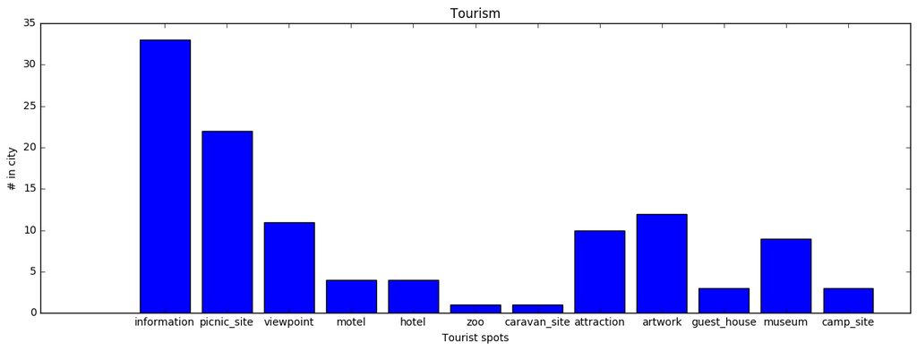

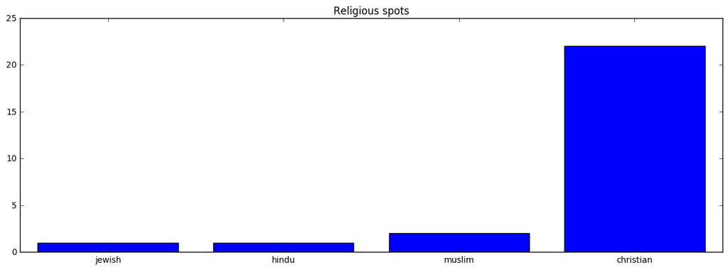

```python
import math as mt
%pylab inline
import matplotlib.patches as mpatches
import matplotlib.pyplot as plt

print "INTERESTING FACTS", "\n"

## Number of unique users
cur.execute("SELECT COUNT(DISTINCT(uid)) FROM (SELECT uid FROM nodes UNION ALL SELECT uid FROM ways);")
all_uid = cur.fetchall()
print "Number of unique users"
print all_uid[0][0], "\n"

cur.execute("SELECT uid, COUNT(uid) FROM (SELECT uid FROM nodes UNION ALL SELECT uid FROM ways)")


## Number of nodes
cur.execute("SELECT COUNT(*) FROM nodes;")
all_nodes = cur.fetchall()
print "Number of nodes"
print all_nodes[0][0], "\n"

## Number of ways
cur.execute("SELECT COUNT(*) FROM ways;")
all_ways = cur.fetchall()
print "Number of ways"
print all_ways[0][0], "\n"


## Different tourist spots
cur.execute("SELECT *, COUNT(value) FROM nodes_tags WHERE key ='tourism' GROUP BY value")
all_rows = cur.fetchall()
print "Tourist spots in Toronto"
print all_rows, "\n"

cur.execute("SELECT COUNT(*) FROM nodes_tags WHERE key='tourism' ")
all_tours = cur.fetchall()
print "Number of different tourist spots"
print all_tours[0][0], "\n"

## Graph different tourist spots
tourism = {}
for tours in all_rows:
    tourism[tours[2]] = tours[4]

plt.figure(figsize=(15,5))
plt.bar(range(len(tourism)), tourism.values(), align='center')
plt.xticks(range(len(tourism)), tourism.keys())
plt.xlabel("Tourist spots")
plt.ylabel("# in city")
plt.title("Tourism")

## Different types of cuisines
cur.execute("SELECT value, COUNT(value) FROM nodes_tags WHERE key='religion' GROUP BY value")
all_religions = cur.fetchall()
print "Religious spots in toronto"
print all_religions, "\n"

religions = {}

for religion in all_religions:
    religions[religion[0]] = religion[1]

plt.figure(figsize=(15,5))
plt.bar(range(len(religions)), religions.values(),align='center')
plt.xticks(range(len(religions)), religions.keys())
plt.title("Religious spots")
```

INTERESTING FACTS

The first couple queries reveal number of unique users, nodes and ways. The first graph reveals information about tourist spots, how many of each type of tourist spots there are in the country. The second graph provides insight into the different specific religious structures there are in the city. As expected Christian related spots so aka churches are the most common which makes sense because Canada is a Christian dominant country.

BENEFITS AND ISSUES OF CLEANING THE DATA

There is also room for improvement in this data. For starters like the querying and programming reveals there are province name errors. But before we can fix the name of the province, that is make them consistent, in this case make them "ON" for Ontario there is another small "unnecessary" tag in this data that is causing more problems and cleaning than necessary.

Benefit:

I touched on this slightly earlier but its the distinction between "state" and "province". The problem here is that there are thousands of "addr:state" tags just like there are thousands of "addr:province" tags. Because in Canada we use the word "province" it is better to just stick to province and use that tag the most. Using state sometimes and province other times can cause confusion or one can misunderstand and not clean one portion of the data. This can perhaps reduce space, improve overall consistency and be a general good guideline of where to look for what data. For example, if I wanted to find all provinces I could just search all tag values with "addr:province" and not "addr:state", "addr:province" and any other "keys" used to find the same type of value. To fix this perhaps the users creating the map can come up with a general guideline on how to pinpoint states, cities and/or any other location.

Issue:

The main issue I can think of doing this is consumption of time, it would take some time to get a team that has to find a general guideline to follow in all cases. Also if users in other countries such as the US are auditing this data, they might be looking for keys that are "addr:state" because state is used there more than province, however some querying or finding the tag values through programming can fix this problem.

Benefit #2:

The second benefit I want to discuss is the benefit of cleaning the street types. In many cases "Street" is written as "st", "west" is written as "w" and so on. Writing in shortcut isn't a problem, the problem once again is the inconsistency. If the street types are all the same, it makes it much easier to find values you are looking for and makes it easier to clean, edit and find patterns in the data.

Issue:

The issue of cleaning this data isn't a big one, however if you are changing thousands of street types to their longer version for example, "w"->"west", "st"->"street" you can take up extra additional space that is unnecessary because people can tell by looking at "w" it means west, same with most other shortcuts.

FURTHER IMPROVEMENT

To improve the data to the fullest, I think it's necessary that the team desiging the maps follow a general consistent guideline. For example, make all "st" equal to "street". Another thing to watch out for are spelling errors, businesses such as cuisines don't want to be missed out because their type was spelled wrong on the map. Or the map can have another option, that is "report" option for data analysts, everytime a data analyst sees an error they can report the error with a message on what to fix specifically. That way maps can improve in no time, or maybe if any individual finds an error they can report it as well. The data scientists can check the error for themselves first before passing it onto the team that fixes the maps.

CONCLUSION

Overall the data is reliable, all locations(nodes) include their lattitudes, longitudes and the tag "k" values provide sufficient information about the place. Throughout this data I focused on cleaning the "addr:street", "addr:province" and "tag k="cuisine" " portions of the xml file because I found those to be the most inconsistent. Street types were written different from one place to another, province name was written differently throughout the xml file and in some cases spelled incorrectly. I chose "addr:street" and "addr:province" because they are common to have inconsistencies as I also saw in the case study earlier when we did the data wrangling, and also because these two things are crucial for an accurate map. I also looked into other tag keys for nodes and ways such as "addr:postcode" and "addr:city" and found them to be consistent.